# S04 - Frecuencia de Siniestros

Juan Carlos Martínez-Ovando

Primavera 2017

# Frecuencia de Siniestros

En esta seccion consideramos que estamos trabajando dentro de la clase de **modelos de riesgo colectivo**, donde
$$S=\sum_{j=1}^{N}X_{j},$$
donde $N$ es el numero de siniestros en un portafolio de seguros de tamanio $J$ y $X_j$ es el monto de reclamo (condicional en que haya siniestro). De lo anterior se sigue que el soporte de las $X_j$s es $\mathcal{X}=(0,\infty).$

En esta sesion prestaremos atencion a algunos modelos de probabilidad empleados para describir la incertidumbre entorno a $N$.

## 1. Distribucion binomial

Se dice que $N$ sigue una distribucion binomial, $Bin(n|J,\theta)$, cuando
$$\begin{eqnarray}
\mathbb{E}(N) & = & J\theta
\nonumber \\
var(N) & = & J\theta(1-\theta)
\nonumber \\
M_{N}(t) & = & \left(\theta e^{t}+1-\theta\right)^{J}
\nonumber \\
P_{N}(t) & = & \left(\theta t+1-\theta\right)^{J}.
\nonumber
\end{eqnarray}$$

El parametro $0<\theta<1$ se interpreta como $\mathbb{P}(\text{siniestro})$ para cualquier poliza dentro del portafolio de seguros, referente al periodo de operacion.

La distribucion binomial se usa en el contexto donde cada poliza en el portafiolio puede producir solo un reclamo dentro del periodo de operacion.

## 2. Distribucion binomial-negativa

Se dice que $N$ tiene una distribucion binomial negativa, $BinNeg(n|r,\theta)$ si
$$\begin{eqnarray}
\mathbb{E}(N) & = & \frac{r(1-\theta)}{\theta}
\nonumber \\
var(N) & = & \frac{r(1-\theta)}{\theta^{2}}
\nonumber \\
M_{N}(t) & = & \left(\frac{\theta}{1-(1-\theta)e^{t}}\right)^{r}
\nonumber \\
P_{N}(t) & = & \left(\frac{\theta}{1-(1-\theta)t}\right)^{r},
\nonumber
\end{eqnarray}$$

para $r$ entero positivo y $0<\theta<1$.

Esta distribucion se emplea en el caso de portafolios en los que cada polia puede producir mas de un reclamo dentro del periodo de operacion.

## 3. Distribucion Poisson

La distribucion Poisson es quizas la distribucion de frecuencias de siniestros mas empleada en la practica y en la teoria.

Se dice que $N$ se distrobuye Poisson, $Po(n|\lambda)$ cuando,
$$\begin{eqnarray}
\mathbb{E}(N) & = & \lambda
\nonumber \\
var(N) & = & \lambda
\nonumber \\
M_{N}(t) & = & \exp\left\{\lambda\left(e^{t}-1\right)\right\}
\nonumber \\
P_{N}(t) & = & \exp\left\{\lambda\left(t-1\right)\right\},
\nonumber
\end{eqnarray}$$

donde $\lambda$ es la tasa de intensidad de siniestros referente al periodo de operacion.

Al igual que la distribucion binomial negativa, esta distribucion se emplea en el caso donde cada poliza dentro del portafolio de seguros puede producir mas de un siniestro en el periodo de operacion.

## 4. Distribuciones $(\alpha,\beta,0)$

Una distribucion ampliamente estudiada en las ciencias actuariales es la que se conoce como $(\alpha,\beta,0)$, definida para ciertos valores de $\alpha$ y $\beta$ reales. Esta distribucion se define como el conjunto de masas de probabilidad
$$p_n = \mathbb{P}(N=n),$$
tal que la siguiente recursion se cumple,
$$p_n = \left(\alpha +\frac{\beta}{n}\right)p_{n-1},$$
para $n=1,2,\ldots$ sujeto a
$$p_0 = \mathbb{P}(N=0),$$
considerado como fijo.

El uso de las distribuciones $(\alpha,\beta,0)$ descansa principalmente en el uso de formulas de recursion (especificamente la recursion de Panjer) para calcular la distribucion de $S$, el monto agregado de riesgo.

Se puede ver que las tres distriuciones anteriores (binomial, binomial negativa y Poisson) son un caso particular de esta distribucion:

- Binomial
  $$\begin{eqnarray}
  p_0 & = & (1-\theta)^{J}
  \nonumber \\
  \alpha & = & -\frac{\theta}{1-\theta}
  \nonumber \\
  \beta & = & (J+1)\frac{\theta}{1-\theta}
  \nonumber
  \end{eqnarray}$$
- Binomial negativa
  $$\begin{eqnarray}
  p_0 & = & (1+\theta)^{-r}
  \nonumber \\
  \alpha & = & \frac{\theta}{1+\theta}
  \nonumber \\
  \beta & = & (r-1)\frac{\theta}{1+\theta}
  \nonumber
  \end{eqnarray}$$
- Poisson
  $$\begin{eqnarray}
  p_0 & = & e^{-\lambda}
  \nonumber \\
  \alpha & = & 0
  \nonumber \\
  \beta & = & \lambda
  \nonumber
  \end{eqnarray}$$

### Comparativo

Veamos un comparativo de estas distribuciones.

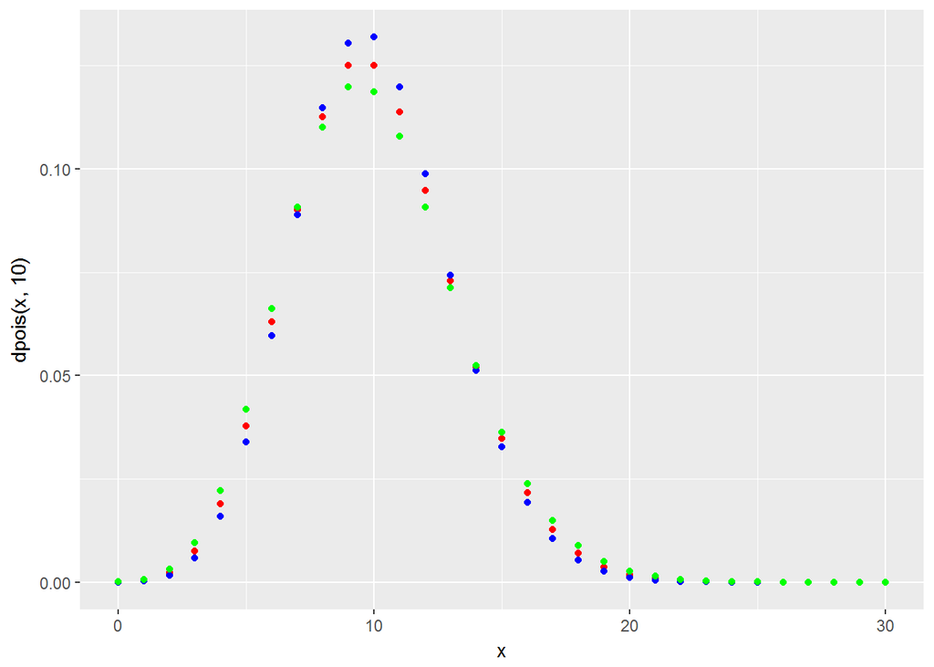

```r
rm(list=ls())
require("ggplot2")
# Distribucion geometrica
ggplot(data.frame(x=c(0:30)), aes(x)) +
    geom_point(aes(y=dpois(x, 10)), colour="red",
               ylab = "masa de probabildad", xlab="N") +
    geom_point(aes(y=dbinom(x, 100, 0.1)), colour="blue") +
    geom_point(aes(y=dnbinom(x, 90, 0.9)), colour="green")
```

- En `azul` marcamos las masas de probabilidad de la distribucion binomial
- En `verde` marcamos las masas de probabilidad de la distribucion binomial-negativa
- En `rojo` marcamos las masas de probabilidad de la distribucion Poisson